# Volcanoes

Jennessa Brunette

# Volcano Analysis

This is an analysis of the Volcano data set. This data comes from the Smithsonian Institution and was taken as early as 1883.

# About Our Data

This data provides information on 958 volcanoes. It includes variables such as volcano name, region, country and eruption year.

# Interesting Questions to Ask

- Which volcano had the most recent eruption?
- Which region has the most eruptions?

# Hypothesis

- I hypothesize the region with the most eruptions will be South America

```r
#Load the tidyverse
library(tidyverse)
library(kableExtra)
#install.packages("tidymodels")
library(tidymodels)
#install.packages("skimr")
library(skimr)

library(ggplot2)
```

Here I found the count of volcanoes observed. There were 958.

```r
count (volcano)
```

| n |
| --- |
| 958 |

```r
volcano %>%
  head() %>%
  kable() %>%
  kable_styling(c("striped", "hover"))
```

| volcano_number | volcano_name | primary_volcano_type | last_eruption_year | country | region | subregion | latitude | longitude | elevation | tectonic_settings | evidence_category | major_rock_1 | major_rock_2 | major_rock_3 | major_rock_4 | major_rock_5 | minor_rock_1 | minor_rock_2 | minor_rock_3 | minor_rock_4 | minor_rock_5 | population_within_5_km | population_within_10_km | population_within_30_km | population_within_100_km |
| --- | --- | --- | --- | --- | --- | --- | --- | --- | --- | --- | --- | --- | --- | --- | --- | --- | --- | --- | --- | --- | --- | --- | --- | --- | --- |
| 283001 | Abu | Shield(s) | -6850 | Japan | Japan, Taiwan, Marianas | Honshu | 34.500 | 131.600 | 641 | Subduction zone / Continental crust (>25 km) | Eruption Dated | Andesite / Basaltic Andesite | Basalt / Picro-Basalt | Dacite |  |  |  |  |  |  |  | 3597 | 9594 | 117805 | 4071152 |
| 355096 | Acamarachi | Stratovolcano | Unknown | Chile | South America | Northern Chile, Bolivia and Argentina | -23.292 | -67.618 | 6023 | Subduction zone / Continental crust (>25 km) | Evidence Credible | Dacite | Andesite / Basaltic Andesite |  |  |  |  |  |  |  |  | 0 | 7 | 294 | 9092 |
| 342080 | Acatenango | Stratovolcano(es) | 1972 | Guatemala | México and Central America | Guatemala | 14.501 | -90.876 | 3976 | Subduction zone / Continental crust (>25 km) | Eruption Observed | Andesite / Basaltic Andesite | Dacite |  |  |  | Basalt / Picro-Basalt |  |  |  |  | 4329 | 60730 | 1042836 | 7634778 |
| 213004 | Acigol-Nevsehir | Caldera | -2080 | Turkey | Mediterranean and Western Asia | Turkey | 38.537 | 34.621 | 1683 | Intraplate / Continental crust (>25 km) | Eruption Dated | Rhyolite | Dacite | Basalt / Picro-Basalt | Andesite / Basaltic Andesite |  |  |  |  |  |  | 127863 | 127863 | 218469 | 2253483 |
| 321040 | Adams | Stratovolcano | 950 | United States | Canada and Western USA | USA (Washington) | 46.206 | -121.490 | 3742 | Subduction zone / Continental crust (>25 km) | Eruption Dated | Andesite / Basaltic Andesite | Basalt / Picro-Basalt |  |  |  | Dacite |  |  |  |  | 0 | 70 | 4019 | 393303 |
| 283170 | Adatarayama | Stratovolcano(es) | 1996 | Japan | Japan, Taiwan, Marianas | Honshu | 37.647 | 140.281 | 1728 | Subduction zone / Continental crust (>25 km) | Eruption Observed | Andesite / Basaltic Andesite |  |  |  |  | Dacite | Basalt / Picro-Basalt |  |  |  | 428 | 3936 | 717078 | 5024654 |

```r
# Get the Data

volcano <- readr::read_csv('https://raw.githubusercontent.com/rfordatascience/tidytuesday/master/data/2020/2020-05-12/volcano.csv')
eruptions <- readr::read_csv('https://raw.githubusercontent.com/rfordatascience/tidytuesday/master/data/2020/2020-05-12/eruptions.csv')
events <- readr::read_csv('https://raw.githubusercontent.com/rfordatascience/tidytuesday/master/data/2020/2020-05-12/events.csv')
tree_rings <- readr::read_csv('https://raw.githubusercontent.com/rfordatascience/tidytuesday/master/data/2020/2020-05-12/tree_rings.csv')
sulfur <- readr::read_csv('https://raw.githubusercontent.com/rfordatascience/tidytuesday/master/data/2020/2020-05-12/sulfur.csv')
# Or read in with tidytuesdayR package (https://github.com/thebioengineer/tidytuesdayR)
# PLEASE NOTE TO USE 2020 DATA YOU NEED TO USE tidytuesdayR version ? from GitHub

# Either ISO-8601 date or year/week works!

volcano %>%
  head()
```

| volcano_number | volcano_name | primary_volcano_type | last_eruption_year | country | region | subregion | latitude | longitude | elevation | tectonic_settings | evidence_category | major_rock_1 | major_rock_2 | major_rock_3 | major_rock_4 | major_rock_5 | minor_rock_1 | minor_rock_2 | minor_rock_3 | minor_rock_4 | minor_rock_5 | population_within_5_km | population_within_10_km | population_within_30_km | population_within_100_km |
| --- | --- | --- | --- | --- | --- | --- | --- | --- | --- | --- | --- | --- | --- | --- | --- | --- | --- | --- | --- | --- | --- | --- | --- | --- | --- |
| 283001 | Abu | Shield(s) | -6850 | Japan | Japan, Taiwan, Marianas | Honshu | 34.500 | 131.600 | 641 | Subduction zone / Continental crust (>25 km) | Eruption Dated | Andesite / Basaltic Andesite | Basalt / Picro-Basalt | Dacite |  |  |  |  |  |  |  | 3597 | 9594 | 117805 | 4071152 |
| 355096 | Acamarachi | Stratovolcano | Unknown | Chile | South America | Northern Chile, Bolivia and Argentina | -23.292 | -67.618 | 6023 | Subduction zone / Continental crust (>25 km) | Evidence Credible | Dacite | Andesite / Basaltic Andesite |  |  |  |  |  |  |  |  | 0 | 7 | 294 | 9092 |
| 342080 | Acatenango | Stratovolcano(es) | 1972 | Guatemala | México and Central America | Guatemala | 14.501 | -90.876 | 3976 | Subduction zone / Continental crust (>25 km) | Eruption Observed | Andesite / Basaltic Andesite | Dacite |  |  |  | Basalt / Picro-Basalt |  |  |  |  | 4329 | 60730 | 1042836 | 7634778 |
| 213004 | Acigol-Nevsehir | Caldera | -2080 | Turkey | Mediterranean and Western Asia | Turkey | 38.537 | 34.621 | 1683 | Intraplate / Continental crust (>25 km) | Eruption Dated | Rhyolite | Dacite | Basalt / Picro-Basalt | Andesite / Basaltic Andesite |  |  |  |  |  |  | 127863 | 127863 | 218469 | 2253483 |
| 321040 | Adams | Stratovolcano | 950 | United States | Canada and Western USA | USA (Washington) | 46.206 | -121.490 | 3742 | Subduction zone / Continental crust (>25 km) | Eruption Dated | Andesite / Basaltic Andesite | Basalt / Picro-Basalt |  |  |  | Dacite |  |  |  |  | 0 | 70 | 4019 | 393303 |
| 283170 | Adatarayama | Stratovolcano(es) | 1996 | Japan | Japan, Taiwan, Marianas | Honshu | 37.647 | 140.281 | 1728 | Subduction zone / Continental crust (>25 km) | Eruption Observed | Andesite / Basaltic Andesite |  |  |  |  | Dacite | Basalt / Picro-Basalt |  |  |  | 428 | 3936 | 717078 | 5024654 |

```r
#install.packages("tidymodels")
library(tidymodels)

my_data_splits <- initial_split(volcano, prop = 0.5)

exploratory_data <- training(my_data_splits)
test_data <- testing(my_data_splits)
```

# Which volcano had the most recent eruption?

```r
exploratory_data %>%
  group_by(last_eruption_year) %>%
  summarize (volcano_name)
```

| last_eruption_year | volcano_name |
| --- | --- |
| -104 | Vulsini |
| -1170 | Zuni-Bandera |
| -1200 | Fremrinamar |
| -1200 | Naolinco Volcanic Field |
| -1250 | Aguilera |
| -1320 | Yucamane |
| -1350 | Yellowstone |
| -1350 | Toluca, Nevado de |
| -150 | Ubehebe Craters |
| -160 | Muria |

[output cut: 469 more lines]

```r
collapse = "unknown"
```

From this table we can view last eruption years for the volcanoes in the data set. I found that the last eruption year was 2020 and 21 volcanoes erupted that year. This can be shown in rows 30 and 31 to see specific names of those that erupted that year.

# Which region has had the most eruptions?

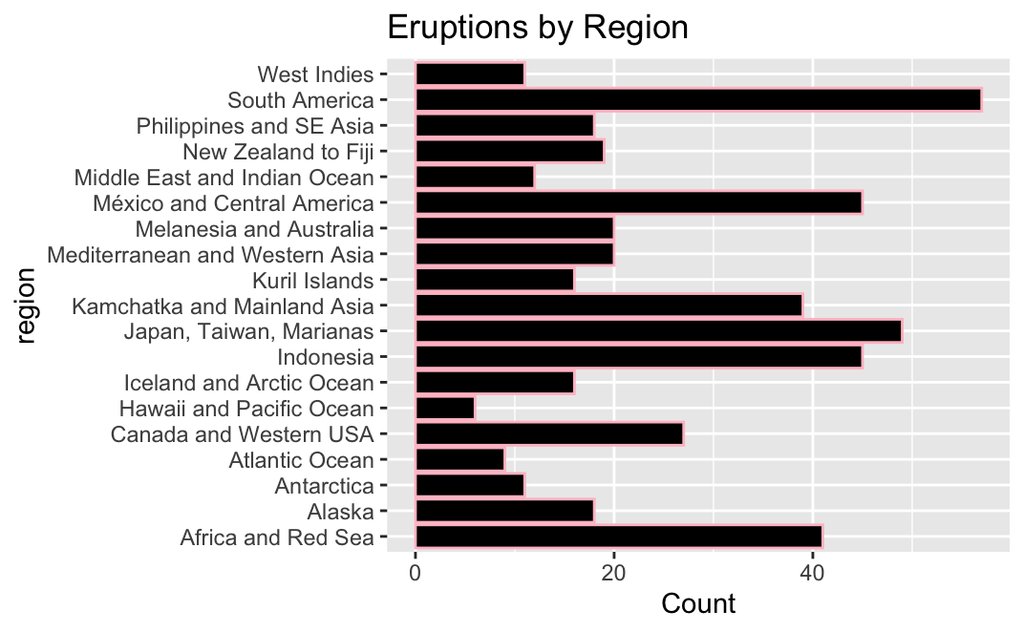

```r
exploratory_data %>%
  ggplot() +
  geom_bar(mapping = aes(x = region), color = "pink", fill = "black") +
  labs(title = "Eruptions by Region",x= "region", y= "Count") +
  coord_flip()
```

```r
NA
NA
```

# Conclusion

In conclusion the volcano data provided useful information regarding volcanic eruptions throughout the years. My hypothesis held true in that South America is the region with most eruptions. I knew Chile and peru were countries that were located within the Ring of Fire, so I had some prior knowledge to come to this conclusion.